# 9b_Word2Vec_S3B

## Language Analysis of Alexithymic Discourse

Alexithymic Language Project / raul@psicobotica.com / V2 release (sept 2020)

## Latent Space Feature Engineering (embeddings)

### Using Spanish 3 billion Word2Vec

- Pre-trained model: https://github.com/aitoralmeida/spanish_word2vec
- Get word vectors for Spanish, compute consine similarity and distances.
- Build a embedding representation of documents

## Data set load

```python
import pandas as pd
import numpy as np
import ast
```

## Load features dataset

- Data is already pre-processed (1-Preprocessing).
- Basic NLP features are already calculated (2-Features).
- Some additional BoW features have been added (3-BoW).
- Some additional TF/IDF features have been added (3-TFIDF).
- N-Gram models have been generated (3-N-Grams).
- PoS lists for each document identified (4-Lexicosemantics).
- Writer's personality variables inferred (5-Personality).
- Sentiment analysis (6-Sentiment).
- Topic modeling with LSA (7-LatentSemantic).
- Topic modeling using LDA (8-LantentDirichletAllocation).
- Word2Vec traning (CBoW, SkipGram) (9-Word2Vec).

```python
feats_dataset_path = "https://raw.githubusercontent.com/raul-arrabales/alexithymic-lang/master/data/Prolexitim_v2_features_8.csv"
alex_df = pd.read_csv(feats_dataset_path, header=0, delimiter=";")
```

```python
alex_df.sample(3)
```

|  | Code | TAS20 | F1 | F2 | F3 | Gender | Age | Card | T_Metaphors | T_ToM | ... | AFINN_Words_Int | AFINN_Stems_Int | AFINN_Words_Max | AFINN_Stems_Max | Watson_Sent | Clean_Text | LDA4_Umap2_0 | LDA4_Umap2_1 | LDA10_Topic | LDA4_Topic |
| --- | --- | --- | --- | --- | --- | --- | --- | --- | --- | --- | --- | --- | --- | --- | --- | --- | --- | --- | --- | --- | --- |
| 101 | efb2088a8ab28dc16c158813ae396ec8 | 35 | 13 | 9 | 13 | 2 | 29 | 11 | 0 | 0 | ... | 0.0 | 0.5 | 0 | 1 | 0.000000 | dragones acaban aterrizar cueva preparados sal... | -0.949482 | 6.960877 | 7 | 0 |
| 327 | 15857a4272a38b70f6f0b2eba46d7ca9 | 83 | 35 | 25 | 23 | 2 | 18 | 1 | 0 | 1 | ... | 2.0 | 0.0 | 4 | 0 | -0.883665 | subalterno ignorado aburria indiferencia recibia | -0.635703 | 7.484342 | 1 | 0 |
| 283 | 5bc3c462dc659d90b419ac121963c6a7 | 72 | 29 | 20 | 23 | 2 | 18 | 9VH | 0 | 1 | ... | 1.0 | 0.0 | 2 | 0 | -0.847622 | luego largo viaje regreso ver lugar tan peligr... | 1.710896 | 5.750812 | 8 | 2 |

3 rows × 189 columns

## Load the word vectors

- [Gensim KeyedVectors object](https://radimrehurek.com/gensim/models/keyedvectors.html)

```python
# ! pip install pyemd
```

```
  Using cached pyemd-0.5.1.tar.gz (91 kB)
```

```python
from gensim.models import KeyedVectors
import pyemd
```

```python
# My copy of Spanish 3 Billion Word2Vec (3 GB)
word_vectors = KeyedVectors.load('D:\Dropbox-Array2001\Dropbox\DataSets\Spanish Word2Vec\complete.kv', mmap='r')
```

```python
# Testing Word Vectors
word_vectors.most_similar("niño")
```

```
[('chiquillo', 0.8634899854660034),
 ('bebé', 0.8505645990371704),
 ('crío', 0.842483401298523),
 ('muchacho', 0.7765985727310181),
 ('niñito', 0.7588649988174438),
 ('chico', 0.75837242603302),
 ('cachorro', 0.7369438409805298),
 ('muchachito', 0.7227175831794739),
 ('gatito', 0.6718686819076538),
 ('hombre', 0.6658662557601929)]
```

```python
# Example of one 400 dim vector
word_vectors.get_vector("niño")[0:10]
```

```
memmap([-0.98019737,  0.37916845, -1.6284896 ,  0.74026036,  0.67275375,
        -1.6113833 , -1.4873409 ,  1.6933979 ,  0.30024448,  0.6112603 ],
       dtype=float32)
```

```python
word_vectors.similar_by_vector(
    word_vectors.get_vector("rey") -
    word_vectors.get_vector("hombre") +
    word_vectors.get_vector("mujer"))
```

```
[('reina', 0.7074883580207825),
 ('princesa', 0.6571576595306396),
 ('emperatriz', 0.6183611154556274),
 ('esposa', 0.5992065072059631),
 ('doncella', 0.5958696603775024),
 ('dama', 0.5885562896728516),
 ('infanta', 0.5775145292282104),
 ('mujer', 0.5741763114929199),
 ('concubina', 0.5553327202796936),
 ('hija', 0.5514962673187256)]
```

```python
word_vectors.similar_by_vector(
    word_vectors.get_vector("enfermera") -
    word_vectors.get_vector("mujer") +
    word_vectors.get_vector("hombre"))
```

```
[('enfermero', 0.701812744140625),
 ('hombre', 0.6676745414733887),
 ('individuo', 0.6419544219970703),
 ('celador', 0.6333192586898804),
 ('cirujano', 0.6183052062988281),
 ('médico', 0.6180358529090881),
 ('camillero', 0.6082327365875244),
 ('muchacho', 0.6047707200050354),
 ('chico', 0.6040195822715759),
 ('hombrecillo', 0.5817157030105591)]
```

```python
word_vectors.similarity('guitarra','violín')
```

```
0.6524644
```

```python
sentence1 = 'Obama se dirige a los medios en Illinois'.lower().split()
sentence2 = 'El presidente saluda a la prensa en Chicago'.lower().split()

word_vectors.wmdistance(sentence1, sentence2)
```

```
28.55840932553196
```

```python
word_vectors.distance("media", "hora")
```

```
0.7943162471055984
```

```python
word_vectors.n_similarity(['restaurante', 'chino', 'caro'], ['restaurante', 'japonés', 'barato'])
```

```
0.91821563
```

## Word vectors visualization

```python
from sklearn.manifold import TSNE
import matplotlib.pyplot as plt
```

```python
type(word_vectors.vector_size)
```

```
int
```

```python
sentence = ast.literal_eval(alex_df['Tokens'][4])
print(sentence)
```

```
['hombre', 'desolado', 'porque', 'se', 'ha', 'encontrado', 'a', 'su', 'mujer', 'fallecida']
```

```python
def encode_words(w2v_model, word_list):

    # empty 2D array for word vectors
    num_words = len(word_list)
    num_dims = w2v_model.vector_size
    enc_words = np.zeros((num_words, num_dims))

    # fill the 2D array with actual vectors
    word_idx = 0
    for w in word_list:
        if (w in w2v_model.vocab):
            enc_words[word_idx] = w2v_model.get_vector(w)
        word_idx += 1

    return enc_words
```

```python
enc_words = encode_words(word_vectors, sentence)
```

```python
enc_words.shape
```

```
(10, 400)
```

```python
word_vectors.get_vector('porque')[0:10]
```

```
memmap([ 1.3146172 , -0.9050656 ,  0.44533622,  0.98907256, -0.15550552,
        -1.3354483 ,  1.1072322 ,  1.1321119 ,  0.7280162 ,  1.4634275 ],
       dtype=float32)
```

```python
enc_words[2][0:10]
```

```
array([ 1.31461716, -0.9050656 ,  0.44533622,  0.98907256, -0.15550552,
       -1.33544827,  1.10723221,  1.13211191,  0.7280162 ,  1.46342754])
```

```python
# Reduce dimensionality to 2D
tsne = TSNE(n_components=2)
tsne_2D = tsne.fit_transform(enc_words)
```

```python
tsne_2D
```

```
array([[ -43.740944 ,  155.25958  ],
       [-191.73799  ,  142.84079  ],
       [ 104.74959  ,  158.04675  ],
       [-176.57048  , -152.91917  ],
       [  32.03553  ,    6.0357413],
       [-256.0791   ,   -8.725869 ],
       [-103.849014 ,   -0.9322377],
       [ 119.92907  , -137.7113   ],
       [ 184.26439  ,   13.8616295],
       [ -28.072054 , -150.16994  ]], dtype=float32)
```

```python
# fd with 2D projections of vectors
df_2D = pd.DataFrame(tsne_2D, index=sentence, columns=['tsne_0', 'tsne_1'])
```

```python
df_2D
```

|  | tsne_0 | tsne_1 |
| --- | --- | --- |
| hombre | -43.740944 | 155.259583 |
| desolado | -191.737991 | 142.840790 |
| porque | 104.749588 | 158.046753 |
| se | -176.570480 | -152.919174 |
| ha | 32.035530 | 6.035741 |
| encontrado | -256.079102 | -8.725869 |
| a | -103.849014 | -0.932238 |
| su | 119.929070 | -137.711304 |
| mujer | 184.264389 | 13.861629 |
| fallecida | -28.072054 | -150.169937 |

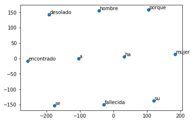

```python
fig = plt.figure()
ax = fig.add_subplot(1, 1, 1)
ax.scatter(df_2D['tsne_0'], df_2D['tsne_1'])

for word, pos in df_2D.iterrows():
    ax.annotate(word, pos+1.8)

plt.show()
```

```python
# let's get all that encapsulated in a function
def plot_encoded_words(vectors, words):

    # Reduce dimensionality to 2D
    tsne = TSNE(n_components=2)
    tsne_2D = tsne.fit_transform(vectors)

    # df with 2D projections of vectors
    df_2D = pd.DataFrame(tsne_2D, index=words, columns=['tsne_0', 'tsne_1'])

    fig = plt.figure(figsize=(12,8))
    ax = fig.add_subplot(1, 1, 1)
    ax.scatter(df_2D['tsne_0'], df_2D['tsne_1'])

    for word, pos in df_2D.iterrows():
        ax.annotate(word, pos+1.8, fontsize=14)

    plt.show()
    return df_2D
```

## Explore vector space semantics geometry

```python
words = "Wikipedia es una enciclopedia libre, políglota y editada de manera colaborativa. Es administrada por la Fundación Wikimedia, una organización sin ánimo de lucro cuya financiación está basada en donaciones. Sus más de 50 millones de artículos en 300 idiomas han sido redactados en conjunto por voluntarios de todo el mundo,5 lo que suma más de 2000 millones de ediciones, y permite que cualquier persona pueda sumarse al proyecto para editarlos, a menos que la página se encuentre protegida contra vandalismos para evitar problemas o disputas".split()
```

```python
encoded = encode_words(word_vectors, words)
```

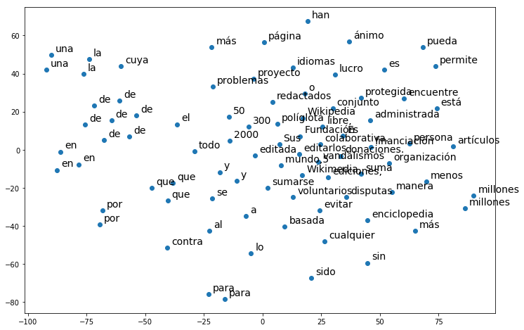

```python
df_2D = plot_encoded_words(encoded, words)
```

We lose the higher dimension geometry due to TSNE 2D projection (same word in different positions)

```python
# synomims of "loco" and "dinero"
words = "alienado - alunado - arrojado - atolondrado - aturdir - aturdirse - chalado - chiflado - ido - vesánico - cuerdo - demente - desequilibrado - desquiciado - enajenado - energúmeno - enloquecer - enloquecido - frenético - grillado - insensato - irresponsable - lunático - majareta - maniaco - maniático - orate - paranoico - perturbado - pirado - poseso - psicópata - raro - sonado - tarumba - tocado - tronado bien - bienes - billete - capital - caudal - cuarto - cuartos - efectivo - finanzas - fondo - fondos - fortuna - guita - hacienda - metálico - moneda - monís - mosca - numerario - oro - parné - pasta - peculio - pela - perra - perras - plata - recurso - recursos - riqueza - tela - tesoro - vuelta".replace('-', '').split()
```

```python
encoded = encode_words(word_vectors, words)
```

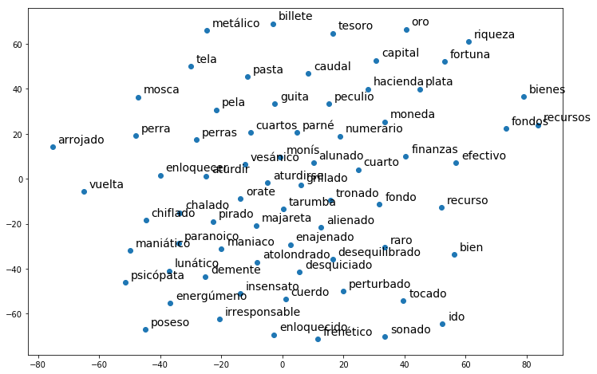

```python
df_2D = plot_encoded_words(encoded, words)
```

It seems to be a good geometric separation of the two classes (synomims of "loco" and "dinero")

## Build document vectors from word vectors

### 1. Document vector as the mean of all word vectors

```python
# Calculates the mean word vector of a list of words using the indicated word2vec model
def get_mean_vector(word2vec_model, words_list):
    # remove out-of-vocabulary words
    words = [word for word in words_list if word in word2vec_model.vocab]
    if len(words) >= 1:
        return np.mean(word2vec_model[words], axis=0)
    else:
        return []
```

```python
# Test item
test_words = alex_df.Tokens.iloc[4]
test_words
```

```
"['hombre', 'desolado', 'porque', 'se', 'ha', 'encontrado', 'a', 'su', 'mujer', 'fallecida']"
```

```python
test_vec = get_mean_vector(word_vectors, test_words)
test_vec.shape
```

```
(400,)
```

```python
# Add the Mean Doc Vector model to features
alex_df['Doc2Vec_3B_Mean'] = alex_df['Tokens'].apply(lambda x: get_mean_vector(word_vectors, x))
```

```python
alex_df.head()
```

|  | Code | TAS20 | F1 | F2 | F3 | Gender | Age | Card | T_Metaphors | T_ToM | ... | AFINN_Stems_Int | AFINN_Words_Max | AFINN_Stems_Max | Watson_Sent | Clean_Text | LDA4_Umap2_0 | LDA4_Umap2_1 | LDA10_Topic | LDA4_Topic | Doc2Vec_3B_Mean |
| --- | --- | --- | --- | --- | --- | --- | --- | --- | --- | --- | --- | --- | --- | --- | --- | --- | --- | --- | --- | --- | --- |
| 0 | bc39e22ca5dba59fbd97c27987878f56 | 40 | 16 | 9 | 15 | 2 | 22 | 1 | 0 | 1 | ... | 0.0 | 0 | 0 | -0.621737 | niño pensando respuesta deberes sabe | -1.833792 | 3.574054 | 9 | 3 | [0.7490059, 0.43533283, 0.38320902, -0.7258389... |
| 1 | bc39e22ca5dba59fbd97c27987878f56 | 40 | 16 | 9 | 15 | 2 | 22 | 13HM | 0 | 1 | ... | 0.0 | 5 | 0 | -0.946776 | hombre llorando mujer muerto | 6.839204 | 6.678424 | 2 | 2 | [0.24148928, 0.1480174, 0.47298616, -0.5232566... |
| 2 | 20cd825cadb95a71763bad06e142c148 | 40 | 12 | 10 | 18 | 2 | 22 | 1 | 0 | 1 | ... | 5.0 | 8 | 8 | -0.809901 | niño cansado estudiar presionado padres triste... | -2.885869 | 3.666085 | 9 | 2 | [0.6218276, 0.28139102, 0.2586725, -0.7076428,... |
| 3 | 20cd825cadb95a71763bad06e142c148 | 40 | 12 | 10 | 18 | 2 | 22 | 9VH | 0 | 1 | ... | 2.5 | 3 | 4 | -0.964077 | grupo amigos después noche diversión cansados ... | 3.489285 | 10.116968 | 6 | 0 | [0.46048477, 0.19402103, 0.18872687, -0.681791... |
| 4 | 20cd825cadb95a71763bad06e142c148 | 40 | 12 | 10 | 18 | 2 | 22 | 13HM | 0 | 1 | ... | 1.0 | 0 | 2 | -0.599994 | hombre desolado encontrado mujer fallecida | 7.294876 | 7.017851 | 1 | 2 | [0.2878785, 0.2457171, 0.2132683, -0.6135208, ... |

5 rows × 190 columns

### Save Doc2Vec (mean) embeddings

```python
embed_dataset_path = "D:\\Dropbox-Array2001\\Dropbox\\DataSets\\Prolexitim-Dataset\\Prolexitim_v2_Doc2Vec-3B-mean.csv"
alex_df.to_csv(embed_dataset_path, sep=';', encoding='utf-8', index=False)
```

### 2. Document vector as the mean of verbs vectors

```python
# We have pre-identified the lists of PoS for each doc.
alex_df.columns[74:80]
```

```
Index(['Verb_List', 'Noun_List', 'Adjective_List', 'Subord_List',
       'Adverb_List', 'Aux_List'],
      dtype='object')
```

```python
# Add the Mean Doc Vector model to features
alex_df['Doc2Vec_3B_MeanVerbs'] = alex_df['Verb_List'].apply(lambda x: get_mean_vector(word_vectors, x))
```

```python
alex_df[['Doc2Vec_3B_Mean','Doc2Vec_3B_MeanVerbs']].sample(6)
```

|  | Doc2Vec_3B_Mean | Doc2Vec_3B_MeanVerbs |
| --- | --- | --- |
| 275 | [0.3859075, 0.26425925, 0.14062537, -0.6131673... | [0.39115158, 0.40444887, 0.16790439, -0.671190... |
| 273 | [0.4908332, 0.3424573, 0.24496277, -0.61977977... | [0.48970157, 0.3391655, 0.24139136, -0.5268357... |
| 4 | [0.2878785, 0.2457171, 0.2132683, -0.6135208, ... | [0.31907308, 0.23436198, 0.26213625, -0.619429... |
| 294 | [0.3084835, 0.16102402, 0.17961502, -0.5107211... | [0.27842346, -0.23982938, 0.37497815, -0.52850... |
| 263 | [0.38050228, 0.2174078, 0.245643, -0.5274073, ... | [0.3381176, 0.5864552, 0.43499577, -0.56771207... |
| 101 | [0.33937776, 0.4999248, 0.100655235, -0.638729... | [0.21410929, 0.5898966, -0.19305584, -0.378592... |

```python
# Persist only the new embedding
alex_df.drop('Doc2Vec_3B_Mean', axis='columns', inplace=True)
embed_dataset_path = "D:\\Dropbox-Array2001\\Dropbox\\DataSets\\Prolexitim-Dataset\\Prolexitim_v2_Doc2Vec-3B-mean-verbs.csv"
alex_df.to_csv(embed_dataset_path, sep=';', encoding='utf-8', index=False)
```

### 3. Document vector as the mean of adjectives vectors

```python
# Add the Mean Doc Vector model to features
alex_df['Doc2Vec_3B_MeanAdj'] = alex_df['Adjective_List'].apply(lambda x: get_mean_vector(word_vectors, x))
```

```python
# Persist only the new embedding
alex_df.drop('Doc2Vec_3B_MeanVerbs', axis='columns', inplace=True)
embed_dataset_path = "D:\\Dropbox-Array2001\\Dropbox\\DataSets\\Prolexitim-Dataset\\Prolexitim_v2_Doc2Vec-3B-mean-adjs.csv"
alex_df.to_csv(embed_dataset_path, sep=';', encoding='utf-8', index=False)
```

```python
# Add the Mean Doc Vector model to features
alex_df['Doc2Vec_3B_MeanNoun'] = alex_df['Noun_List'].apply(lambda x: get_mean_vector(word_vectors, x))
```

```python
# Persist only the new embedding
alex_df.drop('Doc2Vec_3B_MeanAdj', axis='columns', inplace=True)
embed_dataset_path = "D:\\Dropbox-Array2001\\Dropbox\\DataSets\\Prolexitim-Dataset\\Prolexitim_v2_Doc2Vec-3B-mean-nouns.csv"
alex_df.to_csv(embed_dataset_path, sep=';', encoding='utf-8', index=False)
```

```python
# Drop the embedding data, once it's saved
alex_df.drop('Doc2Vec_3B_MeanNoun', axis='columns', inplace=True)
```

## Build other features from word vectors

### Coherence / Dispersion of PoS

- Can we obtain a semantic coherence metric based on word vectors for verbs, adjs, nouns, etc.?

```python
import seaborn as sns
```

```python
# Let's see how we can calculate this with a test sample
verbs_sample = ast.literal_eval(alex_df['Verb_List'][49])
print(verbs_sample)
```

```
['encontraba', 'tocar', 'sabía', 'mejorar', 'apetecía']
```

```python
verbs_encoded = encode_words(word_vectors, verbs_sample)
```

```python
verbs_encoded.shape
```

```
(5, 400)
```

```python
# Let's calculate the distances
dists = []
for i in range(len(verbs_sample)):
    for j in range(len(verbs_sample)):
        if (i < j):
            dists.append(word_vectors.distance(verbs_sample[i],verbs_sample[j]))
```

```python
# Check
len(dists) == (len(verbs_sample)*len(verbs_sample)-len(verbs_sample))/2
```

```
True
```

```python
# Mean distance
np.mean(dists)
```

```
0.9396089911460876
```

```python
# Std dev.
np.std(dists)
```

```
0.19249940714932293
```

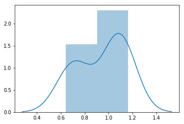

```python
sns.distplot(dists)
```

```python
# Let's include that in a function
def get_dist_mean_std(w2v_model, word_list):
    if (len(word_list) < 2):
        return (0,0)
    else:
        dists = []
        for i in range(len(word_list)):
            for j in range(len(word_list)):
                if (i < j):
                    if ((word_list[i] in w2v_model.vocab) & (word_list[j] in w2v_model.vocab)):
                        dists.append(w2v_model.distance(word_list[i],word_list[j]))
                    else:
                        dists.append(0)
        return (np.mean(dists),np.std(dists))
```

```python
get_dist_mean_std(word_vectors, verbs_sample)
```

```
(0.9396089911460876, 0.19249940714932293)
```

```python
get_dist_mean_std(word_vectors, verbs_sample)[0]
```

```
0.9396089911460876
```

```python
get_dist_mean_std(word_vectors, [])
```

```
(0, 0)
```

```python
# Calculate and save the new features:
alex_df['WV_Verbs_Dist_Mean'] = alex_df.Verb_List.apply(lambda x: get_dist_mean_std(word_vectors, ast.literal_eval(x))[0])
alex_df['WV_Verbs_Dist_Std'] = alex_df.Verb_List.apply(lambda x: get_dist_mean_std(word_vectors, ast.literal_eval(x))[1])
alex_df['WV_Adjs_Dist_Mean'] = alex_df.Adjective_List.apply(lambda x: get_dist_mean_std(word_vectors, ast.literal_eval(x))[0])
alex_df['WV_Adjs_Dist_Std'] = alex_df.Adjective_List.apply(lambda x: get_dist_mean_std(word_vectors, ast.literal_eval(x))[1])
alex_df['WV_Nouns_Dist_Mean'] = alex_df.Noun_List.apply(lambda x: get_dist_mean_std(word_vectors, ast.literal_eval(x))[0])
alex_df['WV_Nouns_Dist_Std'] = alex_df.Noun_List.apply(lambda x: get_dist_mean_std(word_vectors, ast.literal_eval(x))[1])
```

```python
alex_df['WV_Verbs_Dist_Mean'].describe()
```

```
count    338.000000
mean       0.698889
std        0.372997
min        0.000000
25%        0.689562
50%        0.860442
75%        0.931020
max        1.284155
Name: WV_Verbs_Dist_Mean, dtype: float64
```

```python
alex_df['WV_Verbs_Dist_Std'].describe()
```

```
count    338.000000
mean       0.138762
std        0.115825
min        0.000000
25%        0.000000
50%        0.164075
75%        0.222167
max        0.488110
Name: WV_Verbs_Dist_Std, dtype: float64
```

```python
# Save new features
alex_df.columns[len(alex_df.columns)-6:len(alex_df.columns)]
```

```
Index(['WV_Verbs_Dist_Mean', 'WV_Verbs_Dist_Std', 'WV_Adjs_Dist_Mean',
       'WV_Adjs_Dist_Std', 'WV_Nouns_Dist_Mean', 'WV_Nouns_Dist_Std'],
      dtype='object')
```

```python
# Save Updated features dataset
Feats_9_path = "D:\\Dropbox-Array2001\\Dropbox\\DataSets\\Prolexitim-Dataset\\Prolexitim_v2_features_9.csv"
alex_df.to_csv(Feats_9_path, sep=';', encoding='utf-8', index=False)
```